# BCB420-A1

## Packages

load all the packages required

```r
if (!requireNamespace("BiocManager", quietly = TRUE))
  install.packages("BiocManager")
if (!requireNamespace("GEOmetadb", quietly = TRUE))
  BiocManager::install("GEOmetadb")
if(!requireNamespace("edgeR", quietly = TRUE))
  BiocManager::install("edgeR")
if(!requireNamespace("biomaRt", quietly = TRUE))
  BiocManager::install("biomaRt")

library("BiocManager")
library("GEOmetadb")
library("edgeR")
library("biomaRt")
library("knitr")

if(!file.exists('GEOmetadb.sqlite')) getSQLiteFile()
```

## Data selection

create a sql searches in the GEOmetadb.sqlite, looking for dataset with submission date after 2015, associated with cancer, homo sapians, and high-throughput sequencing.

```r
sql <- paste("SELECT DISTINCT gse.title,gse.gse, gpl.title,",
             " gse.submission_date,",
             " gse.supplementary_file",
             "FROM",
             "  gse JOIN gse_gpl ON gse_gpl.gse=gse.gse",
             "  JOIN gpl ON gse_gpl.gpl=gpl.gpl",
             "WHERE",
             "  gse.submission_date > '2015-01-01' AND",
             "  gse.title LIKE '%cancer%' AND",
             "  gpl.organism LIKE '%Homo sapiens%' AND",
             "  gpl.technology LIKE '%high-throughput sequencing%' ",
             "  ORDER BY gse.submission_date DESC",sep=" ")
con <- dbConnect(SQLite(),'GEOmetadb.sqlite')
rs <- dbGetQuery(con,sql)
unlist(lapply(rs$supplementary_file,
              FUN = function(x){x <- unlist(strsplit(x,";")) ;
              x <- x[grep(x,pattern="txt",ignore.case=TRUE)];
                tail(unlist(strsplit(x,"/")),n=1)})) [1:30]
```

```
 [1] "GSE166697_Urinary_miRNA_counts.txt.gz"
 [2] "GSE166417_gene_expression.txt.gz"
 [3] "GSE165883_2019.01.15.processed.cpm.txt.gz"
 [4] "GSE165842_vst.txt.gz"
 [5] "GSE165452_ACY241_PRL_RNAseq_no_rRNA_Kallisto_Gene_Counts_matrix.txt.gz"
 [6] "GSE165247_RawCounts_Matrix_2019.txt.gz"
 [7] "GSE165115_Transcriptome_counts.txt.gz"
 [8] "GSE165115_Transcriptome_counts.txt.gz"
 [9] "GSE164730_expression_profile.txt.gz"
[10] "GSE164531_NEDD9_count_table.txt.gz"
[11] "GSE164169_T47DZOE_T47DPCDH.anno.txt.gz"
[12] "GSE163366_otu_tax.txt.gz"
[13] "GSE163374_rat.raw.counts.txt.gz"
[14] "GSE162737_TE-1_mRNA_transcripts.FPKM.txt.gz"
[15] "GSE162726_barcode_supplementary.txt.gz"
[16] "GSE162515_RNAseq_rawCounts.txt.gz"
[17] "GSE162564_22RV1_CountTable.txt.gz"
[18] "GSE162353_S100A9_MDSC_RNAseq.txt.gz"
[19] "GSE162285_gene_raw_counts_matrix.txt.gz"
[20] "GSE162215_all.fpkm.txt.gz"
[21] "GSE162104_count.txt.gz"
[22] "GSE162004_gene_expression.txt.gz"
[23] "GSE161691_TMM_normalized_reads_count_per_million_LNCaP.txt.gz"
[24] "GSE161509_all_samples.fragments_per_gene.txt.gz"
[25] "GSE161502_Raw_Counts.txt.gz"
[26] "GSE161349_Counts_noadj_exons_condense.txt.gz"
[27] "GSE161243_compiled_counts.txt.gz"
[28] "GSE160796_gene_fpkm.txt.gz"
[29] "GSE160693_Normalized_Gene_Counts_Matrix.txt.gz"
[30] "GSE160723_read_counts.txt.gz"
```

```r
rs <- dbGetQuery(con,sql)
counts_files <- rs$supplementary_file[grep(rs$supplementary_file,
                                           pattern = "count", ignore.case = TRUE)]
```

#The datasets choosed is GSE162004, which studied how YTHDF2 inhibits gastric cancer cell growth by regulating FOXC2 signaling pathway.

```r
sfiles <- getGEOSuppFiles('GSE162004')
fnames <- rownames(sfiles)
```

#load the counts data into R and get its header.

```r
data = read.delim(fnames[1],header=TRUE, check.names = FALSE, sep = "\t")
head(data)
```

|  | gene_id | YTHDF2-1_count | YTHDF2-2_count | YTHDF2-3_count | Vector-1_count | Vector-2_count | Vector-3_count |
| --- | --- | --- | --- | --- | --- | --- | --- |
| 1 | ENSMUSG00000028180 | 702 | 937 | 675 | 855 | 869 | 716 |
| 2 | ENSMUSG00000028182 | 51 | 50 | 46 | 35 | 50 | 30 |
| 3 | ENSMUSG00000028185 | 6 | 0 | 0 | 0 | 0 | 0 |
| 4 | ENSMUSG00000028184 | 1174 | 1664 | 1423 | 1058 | 969 | 1156 |
| 5 | ENSMUSG00000028187 | 444 | 689 | 517 | 348 | 385 | 481 |
| 6 | ENSMUSG00000028186 | 0 | 0 | 0 | 1 | 0 | 0 |

```r
kable(head(data), type="html")
```

| gene_id | YTHDF2-1_count | YTHDF2-2_count | YTHDF2-3_count | Vector-1_count | Vector-2_count | Vector-3_count |
| --- | --- | --- | --- | --- | --- | --- |
| ENSMUSG00000028180 | 702 | 937 | 675 | 855 | 869 | 716 |
| ENSMUSG00000028182 | 51 | 50 | 46 | 35 | 50 | 30 |
| ENSMUSG00000028185 | 6 | 0 | 0 | 0 | 0 | 0 |
| ENSMUSG00000028184 | 1174 | 1664 | 1423 | 1058 | 969 | 1156 |
| ENSMUSG00000028187 | 444 | 689 | 517 | 348 | 385 | 481 |
| ENSMUSG00000028186 | 0 | 0 | 0 | 1 | 0 | 0 |

##Data cleaning

#What is the dimension of our data and the colomn names of the data?

```r
dim(data)
```

```
[1] 53465     7
```

```r
colnames(data)
```

```
[1] "gene_id"        "YTHDF2-1_count" "YTHDF2-2_count" "YTHDF2-3_count" "Vector-1_count" "Vector-2_count"
[7] "Vector-3_count"
```

#According to the edgeR protocol, filter weakly expressed and noninformative data. There are 6 samples and therefore the threshold is set to 6.

```r
cpms = cpm(data[, 2:7])
rownames(cpms) <- data[,1]

keep = rowSums(cpms >1) >=6
data_filtered = data[keep,]
```

#now check the dimension of the filtered dataset.

```r
dim(data_filtered)
```

```
[1] 14526     7
```

#The dataset is decreased to 14526 from 53465 after all these cleaning steps.

#Box plot

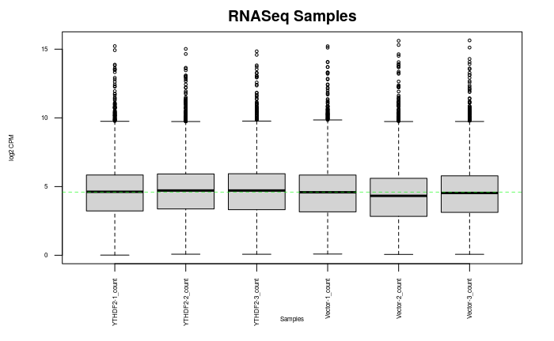

```r
data2plot <- log2(cpm(data_filtered[, 2: ncol(data_filtered)]))
boxplot(data2plot,
        xlab = "Samples",
        ylab = "log2 CPM",
        las = 2,
        cex = 0.5,
        cex.lab = 0.5,
        cex.axis = 0.5,
        main = "RNASeq Samples")
abline(h = median(apply(data2plot,2,median)),
       col = "green",lwd = 0.6, lty = "dashed")
```

#Density Plot

```r
counts_density <-
  apply(log2(cpm(data_filtered[, 2:length(colnames(data_filtered))])),
        2, density)
 #calculate the limits across all the samples
xlim <- 0; ylim <- 0
for (i in 1:length(counts_density)) {
  xlim <- range(c(xlim, counts_density[[i]]$x));
  ylim <- range(c(ylim, counts_density[[i]]$y))
}
 cols <- rainbow(length(counts_density))
 ltys <- rep(1, length(counts_density))

 #plot the first density plot to initialize the plot
 plot(counts_density[[1]],
      xlim=xlim,
      ylim=ylim,
      type="n",
      ylab="Smoothing density of log2-CPM",
      main="Density Plot",
      cex.lab = 0.8)

 #plot each line
 for (i in 1:length(counts_density)) {
   lines(counts_density[[i]],
         col = cols[i],
         lty = ltys[i])
 }
```

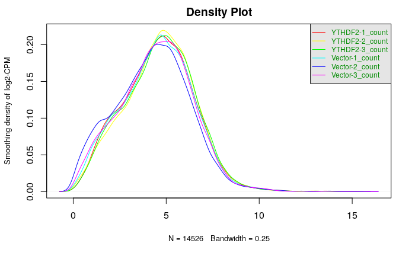

```r
 #create legend
 legend("topright", colnames(data2plot),
 col=cols, lty=ltys, cex=0.75,
 border ="blue", text.col = "green4",
 merge = TRUE, bg = "gray90")
```

#check duplicated genes

```r
summarized_gene_counts <- sort(table(data$gene_id),decreasing = TRUE)
kable(summarized_gene_counts[which(summarized_gene_counts > 1)[1:10]], format = 'html')
```

| Var1 | Freq |
| --- | --- |
| NA | NA |
| NA | NA |
| NA | NA |
| NA | NA |
| NA | NA |
| NA | NA |
| NA | NA |
| NA | NA |
| NA | NA |
| NA | NA |

There is no duplicate genes

#Grouping the data

```r
samples <- data.frame(lapply(colnames(data)[2:7], FUN=function(x){unlist(strsplit(x, split = "_"))[c(1)]}))
colnames(samples) <- colnames(data)[2:7]
rownames(samples) <- c("condition")
samples <- data.frame(t(samples))
samples
```

|  | condition |
| --- | --- |
| YTHDF2-1_count | YTHDF2-1 |
| YTHDF2-2_count | YTHDF2-2 |
| YTHDF2-3_count | YTHDF2-3 |
| Vector-1_count | Vector-1 |
| Vector-2_count | Vector-2 |
| Vector-3_count | Vector-3 |